# Tarea 4

Xymena Ricardez

2025-04-10

1. **Karate**

Considera la red del club de Karate de Zachary. [Acá](https://en.wikipedia.org/wiki/Zachary%27s_karate_club) puedes leer sobre eso. En igraph la gráfica está precargada

```r
library(igraph)
karate<-make_graph("Zachary")
```

- ¿Cuántos nodos y conexiones tiene?

```r
nodos<- vcount(karate)
head(nodos)
```

```
## [1] 34
```

Hay 34 nodos.

- ¿Quiénes son los nodos y cuál es la regla de conexión? La red está basada en las interacciones sociales del club de karate de Zachary, por lo que cada nodo representa a un integrante del club. La regla de conexión esta hecha de acuerdo a la interacción o relación que existía entre las personas.
- ¿Qué tan densa es la red?

```r
edge_density(karate)
```

```
## [1] 0.1390374
```

- ¿Cómo obtienes la matriz de adyacencia?

```r
matriz<- as_adjacency_matrix(karate, sparse = FALSE)
head(matriz)
```

```
##      [,1] [,2] [,3] [,4] [,5] [,6] [,7] [,8] [,9] [,10] [,11] [,12] [,13] [,14]
## [1,]    0    1    1    1    1    1    1    1    1     0     1     1     1     1
## [2,]    1    0    1    1    0    0    0    1    0     0     0     0     0     1
## [3,]    1    1    0    1    0    0    0    1    1     1     0     0     0     1
## [4,]    1    1    1    0    0    0    0    1    0     0     0     0     1     1
## [5,]    1    0    0    0    0    0    1    0    0     0     1     0     0     0
## [6,]    1    0    0    0    0    0    1    0    0     0     1     0     0     0
##      [,15] [,16] [,17] [,18] [,19] [,20] [,21] [,22] [,23] [,24] [,25] [,26]
## [1,]     0     0     0     1     0     1     0     1     0     0     0     0
## [2,]     0     0     0     1     0     1     0     1     0     0     0     0
## [3,]     0     0     0     0     0     0     0     0     0     0     0     0
## [4,]     0     0     0     0     0     0     0     0     0     0     0     0
## [5,]     0     0     0     0     0     0     0     0     0     0     0     0
## [6,]     0     0     1     0     0     0     0     0     0     0     0     0
##      [,27] [,28] [,29] [,30] [,31] [,32] [,33] [,34]
## [1,]     0     0     0     0     0     1     0     0
## [2,]     0     0     0     0     1     0     0     0
## [3,]     0     1     1     0     0     0     1     0
## [4,]     0     0     0     0     0     0     0     0
## [5,]     0     0     0     0     0     0     0     0
## [6,]     0     0     0     0     0     0     0     0
```

- ¿Es una red dirigida, pesada? No es una red dirigida ni pesada ya que no representa como estan asociadas las interacciones.
- Calcula y gráfica la distribución de conectividades

```r
degree<- degree(karate)
dd<- degree_distribution(karate)
tabla<- table (degree)
sum(tabla)
```

```
## [1] 34
```

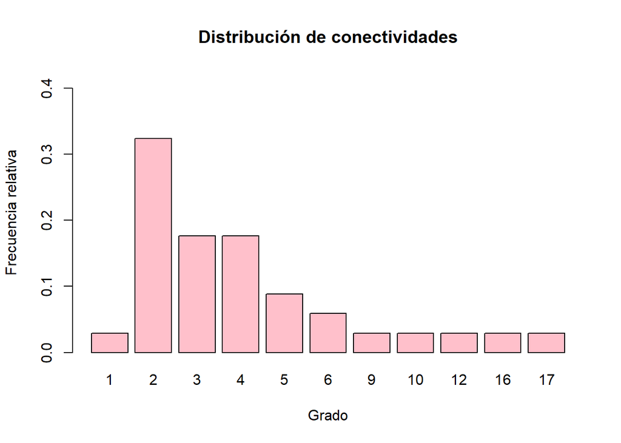

```r
frecrelative<- tabla/sum(tabla)
barplot(frecrelative, xlab = "Grado", ylab = "Frecuencia relativa",
        main ="Distribución de conectividades",
        col = "pink",
        ylim = c(0, max(frecrelative+0.1)))
```

- Calcula el diámetro, la matriz de distancias y la distancia promedio

```r
diameter(karate)
```

```
## [1] 5
```

```r
head(distances(karate))
```

```
##      [,1] [,2] [,3] [,4] [,5] [,6] [,7] [,8] [,9] [,10] [,11] [,12] [,13] [,14]
## [1,]    0    1    1    1    1    1    1    1    1     2     1     1     1     1
## [2,]    1    0    1    1    2    2    2    1    2     2     2     2     2     1
## [3,]    1    1    0    1    2    2    2    1    1     1     2     2     2     1
## [4,]    1    1    1    0    2    2    2    1    2     2     2     2     1     1
## [5,]    1    2    2    2    0    2    1    2    2     3     1     2     2     2
## [6,]    1    2    2    2    2    0    1    2    2     3     1     2     2     2
##      [,15] [,16] [,17] [,18] [,19] [,20] [,21] [,22] [,23] [,24] [,25] [,26]
## [1,]     3     3     2     1     3     1     3     1     3     3     2     2
## [2,]     3     3     3     1     3     1     3     1     3     3     3     3
## [3,]     2     2     3     2     2     2     2     2     2     2     2     3
## [4,]     3     3     3     2     3     2     3     2     3     3     3     3
## [5,]     4     4     2     2     4     2     4     2     4     4     3     3
## [6,]     4     4     1     2     4     2     4     2     4     4     3     3
##      [,27] [,28] [,29] [,30] [,31] [,32] [,33] [,34]
## [1,]     3     2     2     3     2     1     2     2
## [2,]     3     2     2     3     1     2     2     2
## [3,]     3     1     1     2     2     2     1     2
## [4,]     3     2     2     3     2     2     2     2
## [5,]     4     3     3     4     3     2     3     3
## [6,]     4     3     3     4     3     2     3     3
```

```r
matrizdist<- as.matrix(distances(karate))
head(matrizdist)
```

```
##      [,1] [,2] [,3] [,4] [,5] [,6] [,7] [,8] [,9] [,10] [,11] [,12] [,13] [,14]
## [1,]    0    1    1    1    1    1    1    1    1     2     1     1     1     1
## [2,]    1    0    1    1    2    2    2    1    2     2     2     2     2     1
## [3,]    1    1    0    1    2    2    2    1    1     1     2     2     2     1
## [4,]    1    1    1    0    2    2    2    1    2     2     2     2     1     1
## [5,]    1    2    2    2    0    2    1    2    2     3     1     2     2     2
## [6,]    1    2    2    2    2    0    1    2    2     3     1     2     2     2
##      [,15] [,16] [,17] [,18] [,19] [,20] [,21] [,22] [,23] [,24] [,25] [,26]
## [1,]     3     3     2     1     3     1     3     1     3     3     2     2
## [2,]     3     3     3     1     3     1     3     1     3     3     3     3
## [3,]     2     2     3     2     2     2     2     2     2     2     2     3
## [4,]     3     3     3     2     3     2     3     2     3     3     3     3
## [5,]     4     4     2     2     4     2     4     2     4     4     3     3
## [6,]     4     4     1     2     4     2     4     2     4     4     3     3
##      [,27] [,28] [,29] [,30] [,31] [,32] [,33] [,34]
## [1,]     3     2     2     3     2     1     2     2
## [2,]     3     2     2     3     1     2     2     2
## [3,]     3     1     1     2     2     2     1     2
## [4,]     3     2     2     3     2     2     2     2
## [5,]     4     3     3     4     3     2     3     3
## [6,]     4     3     3     4     3     2     3     3
```

```r
mean_distance(karate)
```

```
## [1] 2.4082
```

- Encuentra la trayectoria de los nodos más alejados.

```r
max<- max(distances(karate))
alejados<- which(matrizdist == max, arr.ind = TRUE)
alejados
```

```
##       row col
##  [1,]  17  15
##  [2,]  17  16
##  [3,]  15  17
##  [4,]  16  17
##  [5,]  19  17
##  [6,]  21  17
##  [7,]  23  17
##  [8,]  24  17
##  [9,]  27  17
## [10,]  30  17
## [11,]  17  19
## [12,]  17  21
## [13,]  17  23
## [14,]  17  24
## [15,]  17  27
## [16,]  17  30
```

- Existen nodos con coefeiciente de clusterización 1. ¿Qué significa? Significa que todos los nodos que se encuentran cercanos a este, estan relacionados/conectados entre sí y forman un ambiente cerrado.
- Mide , con al menos tres medidas de centralidad, los nodos más importantes.

```r
centr_degree(karate) #centralidad de grado
```

```
## $res
##  [1] 16  9 10  6  3  4  4  4  5  2  3  1  2  5  2  2  2  2  2  3  2  2  2  5  3
## [26]  3  2  4  3  4  4  6 12 17
##
## $centralization
## [1] 0.3761141
##
## $theoretical_max
## [1] 1122
```

```r
centr_betw(karate) #centralidad de intermediación
```

```
## $res
##  [1] 231.0714286  28.4785714  75.8507937   6.2880952   0.3333333  15.8333333
##  [7]  15.8333333   0.0000000  29.5293651   0.4476190   0.3333333   0.0000000
## [13]   0.0000000  24.2158730   0.0000000   0.0000000   0.0000000   0.0000000
## [19]   0.0000000  17.1468254   0.0000000   0.0000000   0.0000000   9.3000000
## [25]   1.1666667   2.0277778   0.0000000  11.7920635   0.9476190   1.5428571
## [31]   7.6095238  73.0095238  76.6904762 160.5515873
##
## $centralization
## [1] 0.4055572
##
## $theoretical_max
## [1] 17424
```

```r
centr_clo(karate) #centralida de cercanía
```

```
## $res
##  [1] 0.5689655 0.4852941 0.5593220 0.4647887 0.3793103 0.3837209 0.3837209
##  [8] 0.4400000 0.5156250 0.4342105 0.3793103 0.3666667 0.3707865 0.5156250
## [15] 0.3707865 0.3707865 0.2844828 0.3750000 0.3707865 0.5000000 0.3707865
## [22] 0.3750000 0.3707865 0.3928571 0.3750000 0.3750000 0.3626374 0.4583333
## [29] 0.4520548 0.3837209 0.4583333 0.5409836 0.5156250 0.5500000
##
## $centralization
## [1] 0.2981949
##
## $theoretical_max
## [1] 16.24615
```

**Explica e interpreta tus resultados**.

2. **Amigues**

A partir de la red de amigues que vimos en clase, en su versión no ponderada, contesta lo siguiente:

- Escribe una función que calcule el número de amigos que tiene cualquier persona arbitraria y lo compare con el número de los amigos de estos.

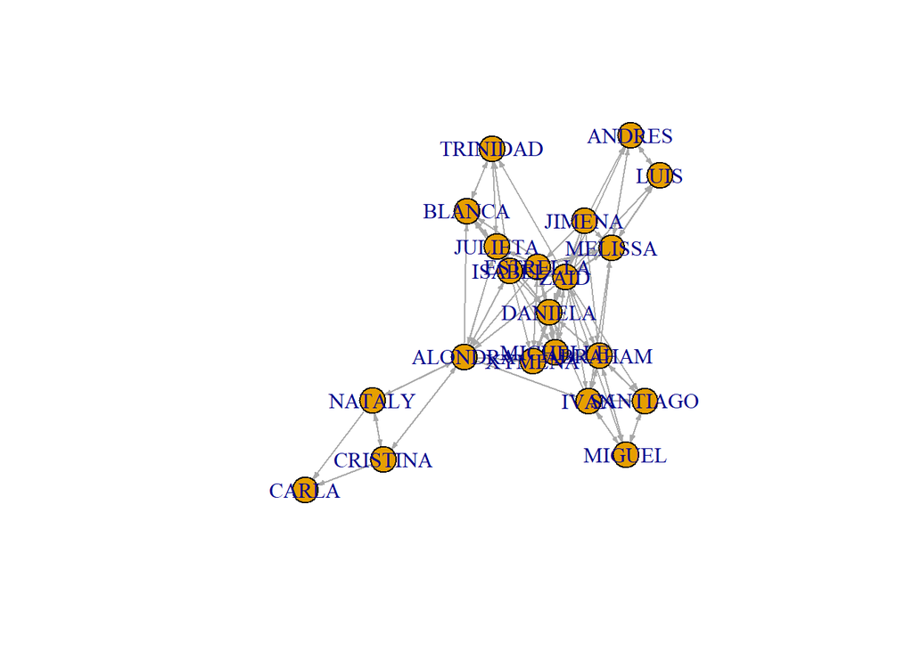

```r
g1<-read.csv("C:/Users/xymen/OneDrive/Documentos/GeneticaF/adjacency_matrix.csv")
View(g1)
rownames(g1)<-g1[,1]
View(g1)
g1<-g1[,-1]
g1<-as.matrix(g1)
diag(g1)<-0
red<-graph_from_adjacency_matrix(g1)
plot(red,vertex.size=15,vertex.size=5,
     edge.arrow.size=0.25,layout=layout_nicely,vertex.size.label=0.25)
```

```r
amigos <- function(red) {
  nodo <- sample(V(red)$name, 1)
  aminodo <- neighbors(red, nodo, mode = "out")
  tamañoamigos <- length(aminodo)
  amiamigos <- c()
  for (i in seq_along(aminodo)) {
    principal <- aminodo[i]
    amideamigos <- neighbors(red, principal, mode = "out")
    tamañoamideamigo <- length(amideamigos)
    amiamigos <- c(amiamigos, tamañoamideamigo)
  }

cat("Nombre elegido:", nodo, "\n",
      "Su número de amigos es:", tamañoamigos, "\n",
      "El número de amigos de sus amigos es: ", amiamigos, "\n")
}
amigos(red)
```

```
## Nombre elegido: ZAID
##  Su número de amigos es: 16
##  El número de amigos de sus amigos es:  8 7 2 3 6 6 9 5 7 2 4 5 3 3 3 5
```

- Escribe una función que te de la trayectoria más larga entre dos nodos arbitrarios de la red.

```r
trayectoria<- function(red){
matrizdist <- distances(red)
max<- max(distances(red))
alejados<- which(matrizdist == max, arr.ind = TRUE)
nodoalejado1 <- rownames(matrizdist)[alejados[1, 1]]
nodoalejado2 <- colnames(matrizdist)[alejados[1, 2]]
cat("nodos mas alejados: ", nodoalejado1,  ",",  nodoalejado2)
}

trayectoria(red)
```

```
## nodos mas alejados:  CARLA , ABRAHAM
```

- Encuentra las dos personas más populares.

```r
degree<- degree(red)
ordenar<- order(degree, decreasing = TRUE)[1:2]
ordenar<-(V(red)$name[ordenar])
cat("las personas más populares son :", ordenar[1], "y", ordenar[2])
```

```
## las personas más populares son : ZAID y ABRAHAM
```

3. **Red PPI**

A partir de la red de interacción proteína-proteína (PPI) de la levadura que se encuentra en la bilbioteca `igraphdata` Elabora un script que conteste lo siguiente:

- Encuentre qué tipo de distribución de conectividades tiene. Haz un ajuste en log-log para ver que tipo de distribución podría ser.

```r
library(igraphdata)
data("yeast")

degree<- degree(yeast)
```

```
## This graph was created by an old(er) igraph version.
## ℹ Call `igraph::upgrade_graph()` on it to use with the current igraph version.
## For now we convert it on the fly...
```

```r
degredistri<- degree_distribution(yeast)
tabla<- table (degree)
sum(tabla)
```

```
## [1] 2617
```

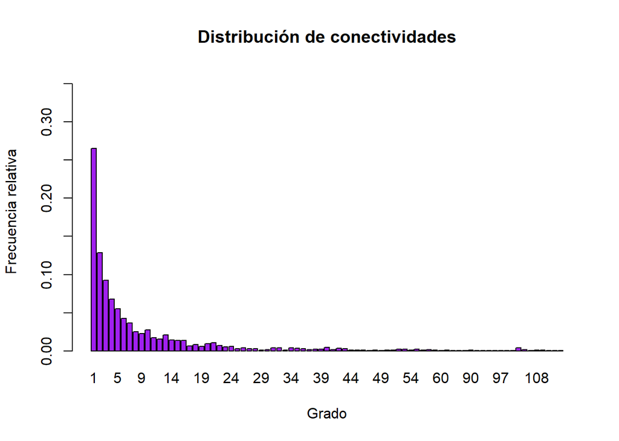

```r
frecrelative<- tabla/sum(tabla)
barplot(frecrelative, xlab = "Grado", ylab = "Frecuencia relativa",
        main ="Distribución de conectividades",
        col = "purple",
        ylim = c(0, max(frecrelative+0.1)))
```

Es una distribución de cola larga.

- Encuentra las diez proteínas más conectadas

```r
degree<- degree(yeast)
conectadas<- sort(degree, decreasing = TRUE)[1:10]
conectadas
```

```
## YPR110C YPL131W YNL178W YIL021W YOL127W YJL063C YBR283C YLR378C YMR260C YBR251W
##     118     115     114     113     113     108     108     108     107     106
```

- Calcula el diámetro y promedio de las distancias

```r
diameter(yeast)
```

```
## [1] 15
```

```r
mean_distance(yeast)
```

```
## [1] 5.095629
```

- Crea una función que, a partir de eliminar al azar un nodo de la red genere el promedio d elas distancias después de eliminar $n=1,2,3,\ldots, 100$ nodos al azar
- Crea una función que elimine las proteínas más conectadas y calcule el promedio de las distancias cad vez que se remueve un nodo.
- Calcula el proemdio del coeficiente de clusterización. ¿Hay proteínas que tengan un coeficiente de clusterización de 1? Eso qué significa.

```r
transitivity(yeast)
```

```
## [1] 0.4686178
```

Discute tus resultados.

4. **Redes biológicas**

Ve a al [Network Repository](https://networkrepository.com/bn-mouse-visual-cortex-1.php) y descarga la red en formato lista de adyacencia. Explica que representam los nodos y las conectividades.

Escribe código que resuelva lo siguiente:

- Cargue y genere una gráfica en `igraph`.
- Genera la gráfica con todos los layouts disponibles.
- Grafica la red con al menos tres medidas de centralidad.
- ¿Qué tan densa es la red?

- Clusteriza la red con al menos tres métodos de clusterización. Gráfica la red con esos métodos.

Explica tus resultados.

5. **Red de coexpresión simulada**

Simula una matriz de expresión con 20 genes en 6 condiciones diferentes.

```r
genes <- matrix(rnorm(20 * 6), nrow = 20, ncol = 6)
rownames(genes) <- paste0("Gen", 1:20)
colnames(genes) <- paste0("Cond", 1:6)
genes
```

```
##             Cond1       Cond2      Cond3       Cond4       Cond5       Cond6
## Gen1   0.49801844  0.46965163  1.5243048 -2.06711072 -1.20275487 -0.40909618
## Gen2   1.90595644  0.34000414  0.6760966 -0.30027340  1.71322611  2.79859386
## Gen3  -0.89764921  1.03879310  0.2570698  0.65504345  0.78895194 -1.17230269
## Gen4   0.86683273 -1.45306773 -1.7797683 -0.47520757 -0.30705502  1.91118466
## Gen5  -0.58079073 -0.02518369 -1.4143493 -0.30636455 -0.35944466 -0.21108992
## Gen6   0.87621219  1.89631691  1.1927649  1.05243217  0.03099863 -1.24394037
## Gen7  -0.63373734  1.69802441  0.5506064 -0.52271202  1.53147513  1.65954506
## Gen8  -1.40706682  0.77049715  0.4148780  0.07857714 -0.57108154  0.55703110
## Gen9  -0.09502006 -1.31534568  1.5920046 -0.22150472  0.23734491 -2.06122419
## Gen10  1.19477982  0.01388942  1.0246864  0.15785629  0.11552871 -0.41387374
## Gen11 -0.58777213 -1.49394022 -0.3093534 -0.80844831  1.51527764  0.41687999
## Gen12  0.43832054 -0.43236567  0.1070606  0.11566232 -0.05504763 -0.45438072
## Gen13  1.08163684 -0.51056424  0.3204934 -1.22334985  0.96099512 -0.65695454
## Gen14 -0.01275492 -0.75082567  0.3836318 -1.12882239  1.80913947  1.17874855
## Gen15  0.14043335 -0.89792454  0.6662591 -0.26441512 -0.18474919  0.49874960
## Gen16  1.68807720  2.26994576 -0.6215780 -0.59015321  0.29457897  0.05250160
## Gen17  1.11472539 -0.39859530  1.6232112  0.39052133  0.28139265 -2.30280056
## Gen18  0.35418048  1.46370779 -0.2902048 -0.60891850 -0.36280048 -1.65654084
## Gen19 -0.26692795 -0.22851517  1.3724760  0.29316804  1.26883129  0.03940027
## Gen20 -0.71246149 -1.11862908 -0.5695580 -1.77053933  0.88685491 -0.29509420
```

- Calcula la correlación entre todos los pares de genes.

```r
cor(genes)
```

```
##             Cond1       Cond2       Cond3       Cond4       Cond5       Cond6
## Cond1  1.00000000  0.14138579  0.11974920  0.02915669 -0.02866084  0.05365095
## Cond2  0.14138579  1.00000000  0.09732124  0.27703143 -0.13719791 -0.07037020
## Cond3  0.11974920  0.09732124  1.00000000  0.23448192  0.05984426 -0.34756485
## Cond4  0.02915669  0.27703143  0.23448192  1.00000000 -0.03041912 -0.23177395
## Cond5 -0.02866084 -0.13719791  0.05984426 -0.03041912  1.00000000  0.38222242
## Cond6  0.05365095 -0.07037020 -0.34756485 -0.23177395  0.38222242  1.00000000
```

- Construye una red de coexpresión utilizando un umbral de correlación > 0.8.

[figure not shown]

```r
cor<- cor(genes)
correlacionyumbral<- cor[abs(cor)>= 0.8]
coexpresion<- graph.adjacency(correlacionyumbral,  mode = "directed")
plot(coexpresion)
```

- Calcula la distribución de grados.
- Identifica si hay módulos o agrupamientos de genes altamente correlacionados.
- Visualiza la red y discute qué tipo de topología tiene.
6. **Comparación de redes**

Construye dos redes:

- Una red aleatoria tipo Erdos-Rényi.
- Una red tipo “scale-free” usando el modelo Barabási–Albert.

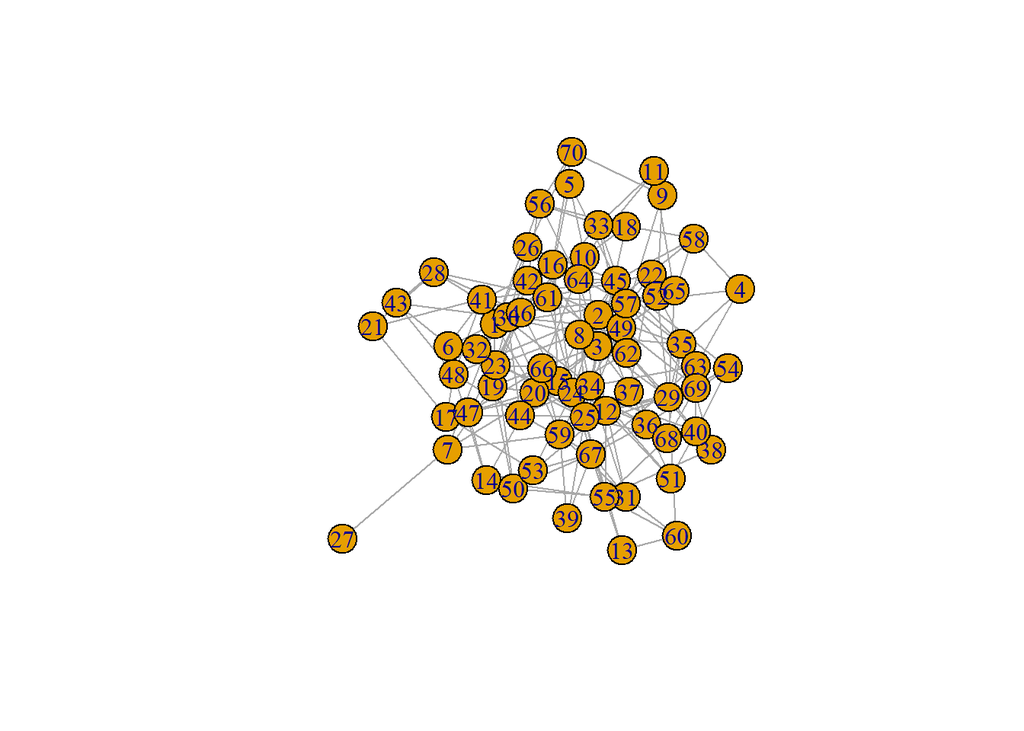

```r
nodos<- 70
conexion<- 3* nodos
erdos<- sample_gnm(nodos , conexion)
plot(erdos)
```

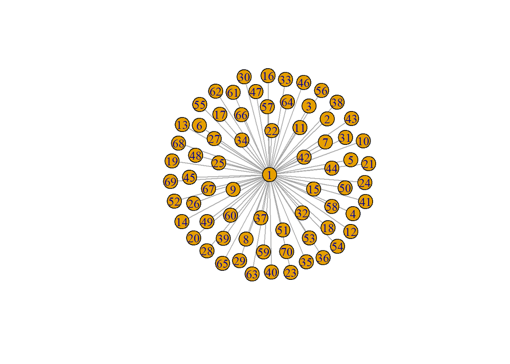

```r
nodos<- 70
conexion<- 3
ba<-sample_pa(nodos, conexion, directed = FALSE)
plot(ba)
```

Para ambas redes:

- Compara su grado promedio, distribución de grados, coeficiente de clusterización y diámetro.

```r
mean(degree(ba))
```

```
## [1] 1.971429
```

```r
mean(degree(erdos))
```

```
## [1] 6
```

```r
degree_distribution(ba)
```

```
##  [1] 0.00000000 0.98571429 0.00000000 0.00000000 0.00000000 0.00000000
##  [7] 0.00000000 0.00000000 0.00000000 0.00000000 0.00000000 0.00000000
## [13] 0.00000000 0.00000000 0.00000000 0.00000000 0.00000000 0.00000000
## [19] 0.00000000 0.00000000 0.00000000 0.00000000 0.00000000 0.00000000
## [25] 0.00000000 0.00000000 0.00000000 0.00000000 0.00000000 0.00000000
## [31] 0.00000000 0.00000000 0.00000000 0.00000000 0.00000000 0.00000000
## [37] 0.00000000 0.00000000 0.00000000 0.00000000 0.00000000 0.00000000
## [43] 0.00000000 0.00000000 0.00000000 0.00000000 0.00000000 0.00000000
## [49] 0.00000000 0.00000000 0.00000000 0.00000000 0.00000000 0.00000000
## [55] 0.00000000 0.00000000 0.00000000 0.00000000 0.00000000 0.00000000
## [61] 0.00000000 0.00000000 0.00000000 0.00000000 0.00000000 0.00000000
## [67] 0.00000000 0.00000000 0.00000000 0.01428571
```

```r
degree_distribution(erdos)
```

```
##  [1] 0.00000000 0.01428571 0.00000000 0.07142857 0.20000000 0.22857143
##  [7] 0.14285714 0.08571429 0.10000000 0.07142857 0.02857143 0.04285714
## [13] 0.01428571
```

```r
transitivity(ba)
```

```
## [1] 0
```

```r
transitivity(erdos)
```

```
## [1] 0.09253247
```

```r
diameter(ba)
```

```
## [1] 2
```

```r
diameter(erdos)
```

```
## [1] 5
```

- Interpreta las diferencias en el contexto de redes biológicas.